# Workbook: Applied R for Migration, Disaster, and Conflict Studies

## Getting started

Welcome! In this workbook you’ll learn the basics of R and RStudio and run your first code.

## What are R and RStudio?

- **R** is the programming language we’ll use for data analysis and visualization.
- **RStudio** is a user-friendly app that makes it easier to write and run R code.

## Step 1 — Install R

1. Go to the CRAN download page for R:
   - https://cran.r-project.org/
2. Click your operating system:
   - Windows / macOS / Linux
3. Download and install using the default options.

## Step 2 — Install RStudio

1. Go to the RStudio Desktop download page:
   - https://posit.co/download/rstudio-desktop/
2. Download the free RStudio Desktop installer.
3. Install it (default options are usually fine).

## Step 3 — Check it works

Open RStudio.

In the Console (bottom-left), type:

```r
1 + 1
```

```
[1] 2
```

# Lesson 1: Projects, working directory, scripts, and running code

## RStudio Projects

RStudio Projects help you keep all files for one project in a single, organized folder. This includes scripts, data, and any outputs you create. Projects are especially useful when you are working on more than one project at the same time.

Each project has its own working directory, which tells R where to look for files and where to save new ones.

### Create a new RStudio Project

1. In RStudio, go to File → New Project
2. Choose New Directory
3. Select New Project
4. Choose a location on your computer and click Create Project

RStudio will open the new project and create a folder on your computer. Save all files related to this project inside that folder.

## The working directory

When you create a new RStudio Project, the working directory is set automatically to the project folder. The working directory is the default location where R looks for files and saves new ones.

It is good practice to organize your project by creating sub-folders, such as `data`, `scripts`, and `figures`. When a project is first created, the only file in the folder is the `.Rproj` file, which you use to reopen the project later.

## The RStudio interface

When you open RStudio or create a new project, you will see a window divided into three main panes.

The console (top left) is where you run R code and see output.

The environment pane (top right) shows the objects and data currently loaded in your R session.

The files, plots, and help pane lets you view files in your project folder, see plots, and access help. When you create a new project, the only file you will see at first is the `.Rproj` file.

## Running code

You can use R as a calculator. For example, try typing `1 + 1` in the Console and pressing Enter.

In practice, we usually write code in scripts rather than directly in the Console. Scripts let you keep a record of your work, edit it later, share it with others, and run the same code again.

To open a new script, go to File > New File > R Script, or click the document icon with a plus sign and select R Script. This will open a new pane where you can write code.

On the first line of your script, type:

```r
1+1
```

```
[1] 2
```

A nice feature of scripts is that you can run multiple lines of code at once. To do this, highlight the lines you want to run and press the Run button or use Ctrl + Enter (Cmd + Enter on macOS).

```r
1 + 1
```

```
[1] 2
```

```r
2 * 4
```

```
[1] 8
```

```r
3 + 8 * 2
```

```
[1] 19
```

## Commenting in a script

Comments are notes you add to your code to explain what it does. In R, anything that comes after `#` on a line is a comment and will not be run as code.

For example:

```r
1 + 1   # I want to add one and one
```

```
[1] 2
```

```r
2 * 4   # This line multiplies two by four
```

```
[1] 8
```

```r
3 + 8 * 2   # You can do multiple operations in one line
```

```
[1] 19
```

## Objects

An object is something that R stores so you can use it later. Objects can be numbers, text, collections of values, data sets, functions, or even groups of other objects.

Every object must have a unique name, called an identifier, which you use to access it in R.

## Creating and naming objects

Objects in R must have unique names. If you reuse a name, the old object is replaced.

Object names must: - start with a letter  
- not contain spaces  
- not use special characters

You can create an object using `<-`, for example:

```r
my_first_object <- 32
```

Once an object is created, you can treat it like any other number and use it in calculations.

```r
my_first_object * 2 + 4
```

```
[1] 68
```

You can also create multiple objects and use them together.

```r
another_object <- 21
my_first_object + another_object
```

```
[1] 53
```

If you want to change the value of an object, you can overwrite it by assigning a new value to the same name.

```r
another_object <- 15
my_first_object + another_object
```

```
[1] 47
```

## A practical example

```r
voting_pop <- 9321800     # Number of people who voted
vote_share <- 0.52       # Vote share of the party

number_of_votes <- voting_pop * vote_share
number_of_votes
```

```
[1] 4847336
```

## Vectors

If you want to work with multiple values at once, you can store them in a vector. A vector is a collection of values created using `c()`.

```r
vote_shares <- c(0.52, 0.44, 0.04)
vote_shares[1]
```

```
[1] 0.52
```

```r
vote_shares[2]
```

```
[1] 0.44
```

```r
vote_shares[3]
```

```
[1] 0.04
```

You can then use the vector to calculate votes for each party:

```r
voting_pop * vote_shares
```

```
[1] 4847336 4101592  372872
```

## Functions, help files, and packages

Functions are what R uses to do things, such as calculations or analyses. A function takes one or more objects as input and returns a result.

Functions are usually followed by parentheses, which contain the arguments.

```r
vote_shares <- c(0.52, 0.44, 0.04)
sum(vote_shares)
```

```
[1] 1
```

Now suppose there are several electoral districts of different sizes. We have the number of voters in each district and the vote share for the first party in each district.

```r
voters_per_district <- c(
  618880, 1286117, 318003, 1037879, 505025,
  493486, 1621599, 976879, 1232128, 1231804
)

vote_share_per_district <- c(
  0.506, 0.583, 0.618, 0.445, 0.219,
  0.461, 0.680, 0.280, 0.532, 0.612
)
```

We can now make some calculations on these vectors. For instance, by running

```r
mean(vote_share_per_district)
```

```
[1] 0.4936
```

```r
cor(vote_share_per_district, voters_per_district)
```

```
[1] 0.4269525
```

If we want to store the correlation above we can do so by running:

```r
size_share_correlation <- cor(vote_share_per_district,voters_per_district)
```

## Default arguments

Many functions in R have default arguments. You can change these by specifying them explicitly.

For example, the `cor()` function uses the Pearson method by default. To use Spearman correlation instead, run:

```r
cor(vote_share_per_district, voters_per_district, method = "spearman")
```

```
[1] 0.3939394
```

## Function help files

You can open a function’s help file by typing a question mark before its name.

```r
?cor
```

If you run the function without naming the argument, R does not know how to interpret `"spearman"` and returns an error.

```r
try(cor(vote_share_per_district, voters_per_district, "spearman"))
```

```
Error in cor(vote_share_per_district, voters_per_district, "spearman") :
  invalid 'use' argument
```

## Packages

Packages are collections of functions (and sometimes data) that extend what R can do. Many packages are available through CRAN.

To install a package, run:

```r
install.packages("dplyr")
library(dplyr)
```

## Calling functions from a package

When a package is loaded, you can usually call its functions by name. Problems can occur if different packages have functions with the same name.

You can avoid this by calling a function directly from a package using `package::function`.

```r
stats::lag(x)
dplyr::lag(x)
```

```r
lag(vote_shares) # lag function from the latest loaded package
```

```
[1] 0.52 0.44 0.04
attr(,"tsp")
[1] 0 2 1
```

```r
stats::lag(vote_shares) # lag function explicitly called from the stats package
```

```
[1] 0.52 0.44 0.04
attr(,"tsp")
[1] 0 2 1
```

```r
dplyr::lag(vote_shares) # lag function explicitly called from the dplyr package
```

```
[1]   NA 0.52 0.44
```

# Lesson 2: Data types and structures in R

## Data types and classes

So far, we have mostly worked with numbers. In R, objects can have different data types, also called classes.

You can check the class of an object using the `class()` function:

```r
vote_shares <- c(0.52,0.44,0.04) # Vote shares of all parties of interest
class(vote_shares)
```

```
[1] "numeric"
```

R has many different object classes. For example, text data are stored as character objects.

If we create a character vector with the names of the electoral districts and try to calculate a correlation with vote shares, it will not work.

```r
# District names
district_names <- c("Capital", "North", "North-East",
                    "North-West", "Western", "Central",
                    "Mountains-West", "Mountains-East",
                    "Big Island", "Small Island") # District names
class(district_names)
```

```
[1] "character"
```

```r
## [1] "character"
# Vote share per district
vote_share_per_district <- c(0.506, 0.583, 0.618,
                             0.445, 0.219, 0.461,
                             0.680, 0.280, 0.532, 0.612)

class(vote_share_per_district)
```

```
[1] "numeric"
```

```r
## [1] "numeric"

# Number of voters in each electoral district
voters_per_district <- c(618880, 1286117, 318003,
                         1037879, 505025, 493486,
                         1621599, 976879, 1232128, 1231804)

try(cor(district_names, vote_shares))
```

```
Error in cor(district_names, vote_shares) : 'x' must be numeric
```

```r
## Error in cor(district_names, vote_shares): 'x' must be numeric
```

## Missing values

R uses `NA` to represent missing values. This is used when a value is not available.

Missing values allow you to keep incomplete data in your object. When using functions like `mean()` or `sum()`, you often need to tell R to remove missing values explicitly.

If you run a function without removing missing values:

```r
vote_shares_with_na <- c(0.52, 0.44, NA, 0.04)
sum(vote_shares_with_na)
```

```
[1] NA
```

```r
sum(vote_shares_with_na, na.rm = TRUE)
```

```
[1] 1
```

## Datasets: vectors, matrices, data frames, and tibbles

So far, we have stored data in vectors. When several vectors describe the same units (for example, districts), they can be combined into a dataset where rows are observations and columns are variables.

Common dataset types in R are:

- Vectors: store a single variable.

```r
scores <- c(10, 15, 20)
```

- Matrices: rectangular data where all values must be the same type.

```r
scores_matrix <- matrix(c(10, 15, 20, 25), nrow = 2)
```

- Data frames: rectangular datasets that can contain different data types in different columns.

```r
scores_df <- data.frame(
  district = c("A", "B"),
  score = c(10, 15)
)
```

- Tibbles: a modern version of data frames with improved behavior and clearer output.

## Tibbles

Tibbles are a modern version of data frames and are part of the tidyverse. They are easier to work with and produce clearer output.

To use tibbles, install and load the tidyverse:

```r
install.packages("tidyverse")
```

```r
library(tidyverse)
```

You can create a tibble using the `tibble()` function. Each vector you include becomes a column in the dataset.

```r
districts <- tibble(
  district_names,
  voters_per_district,
  vote_share_per_district
)
```

The tibble now has a rectangular structure, where rows are districts and columns are variables. This is what we call a dataset.

By default, `tibble()` uses the names of the input vectors as column names. You can set your own names by naming the arguments:

```r
districts <- tibble(
  name = district_names,
  total_voters = voters_per_district,
  vote_share = vote_share_per_district
)
```

You can add a new variable by combining the tibble with another vector:

```r
district_type <- c(
  "urban", "urban", "rural", "urban", "rural",
  "rural", "rural", "urban", "rural", "rural"
)

districts_new <- bind_cols(districts, district_type)
```

## Characters versus factors

When you print a tibble, you can see the class of each variable. The `district_type` variable is a character (`chr`).

If a variable only takes a small number of values, such as `"urban"` and `"rural"`, it is often better to store it as a factor.

You can convert a character variable to a factor using `as_factor()`:

```r
districts <- bind_cols(
  districts,
  urban_rural = as_factor(district_type)
)

districts
```

```
# A tibble: 10 × 4
   name           total_voters vote_share urban_rural
   <chr>                 <dbl>      <dbl> <fct>
 1 Capital              618880      0.506 urban
 2 North               1286117      0.583 urban
 3 North-East           318003      0.618 rural
 4 North-West          1037879      0.445 urban
 5 Western              505025      0.219 rural
 6 Central              493486      0.461 rural
 7 Mountains-West      1621599      0.68  rural
 8 Mountains-East       976879      0.28  urban
 9 Big Island          1232128      0.532 rural
10 Small Island        1231804      0.612 rural
```

## Accessing elements and columns

You can access a column in a tibble using the `$` sign. This returns the column as a vector.

```r
districts$total_voters
```

```
 [1]  618880 1286117  318003 1037879  505025  493486 1621599  976879 1232128
[10] 1231804
```

```r
districts$name
```

```
 [1] "Capital"        "North"          "North-East"     "North-West"
 [5] "Western"        "Central"        "Mountains-West" "Mountains-East"
 [9] "Big Island"     "Small Island"
```

This is useful for applying functions to a single variable:

```r
mean(districts$vote_share)
```

```
[1] 0.4936
```

```r
sd(districts$vote_share)
```

```
[1] 0.1484417
```

You can also use square brackets to access rows and columns. The first number is the row, the second is the column.

```r
districts[3, 4]
```

```
# A tibble: 1 × 1
  urban_rural
  <fct>
1 rural
```

```r
districts[5, ]
```

```
# A tibble: 1 × 4
  name    total_voters vote_share urban_rural
  <chr>          <dbl>      <dbl> <fct>
1 Western       505025      0.219 rural
```

```r
districts[, 1]
```

```
# A tibble: 10 × 1
   name
   <chr>
 1 Capital
 2 North
 3 North-East
 4 North-West
 5 Western
 6 Central
 7 Mountains-West
 8 Mountains-East
 9 Big Island
10 Small Island
```

# Lesson 3: Data in R

## Data import

When importing data into R, the most important thing to know is the file format, which is indicated by the file ending. The file format determines which function you use to read the data.

Common data file formats include: - `.csv`: comma-separated values, widely used across software - `.txt`: text files with a fixed delimiter - `.rds` and `.RData`: R-specific data files - `.dta`: Stata data files - `.xlsx`: Excel files

Regardless of file format, there are two main ways to import data into R.

1. Use the Import Dataset button in the Environment pane. This works for text files (including `.csv`), Excel, Stata, SPSS, and SAS files.
2. Use import functions directly:
   - `read_csv()` for `.csv` files
   - `read_dta()` for Stata files
   - `read_excel()` for Excel files
   - `readRDS()` and `load()` for R data files

As an example, let’s load the GDIS dataset, a global dataset of geocoded disaster locations.

```r
gdis <- read_csv("datasets/gdis.csv")
```

## Checking your data

After importing data, it is good practice to check that it loaded correctly.

You can print the dataset, view the first rows, inspect its structure, and get basic summaries:

```r
head(gdis) # Print the first few rows of the data set
str(gdis) # Print the structure of the data set
colnames(gdis) # Print the variable names of the data set
summary(gdis) # Print a summary of the data set
```

## Data manipulation

Now that we know how to import data and work with the tidyverse, we move on to basic data manipulation. Here, data manipulation means changing a dataset by removing observations or variables, or by creating new variables.

In the tidyverse, data manipulation is done using verb-functions. These are functions named after what they do, such as `filter()`, `select()`, and `mutate()`.

## Filtering data

Filtering means keeping only the observations that meet certain conditions. In the tidyverse, this is done with the `filter()` function.

Filtering returns a new dataset, so it is usually stored as a new object.

```r
gdis_drought <- gdis %>%
  filter(disastertype == "drought")
```

To keep only flood events in Pakistan, we can add another condition to `filter()`:

```r
gdis_flood_pakistan <- gdis %>%
  filter(
    disastertype == "flood",
    country == "Pakistan"
  )
```

## Selecting variables

The `select()` function is used to keep specific columns in a dataset. Unlike `filter()`, it works on variables, not rows.

You can select variables by name or by their column position.

```r
# using variable names (no quotation marks)
gdis_reduced <- gdis %>%
  select(country, year, adm3, disastertype)

# using column positions
gdis_reduced <- gdis %>%
  select(2, 5, 11, 15)

# using column positions and names
gdis_reduced <- gdis %>%
  select(2:5, adm3, disastertype)
```

## Select helpers

Select helpers let you choose variables based on their names. Common helpers include `starts_with()`, `ends_with()`, `contains()`, and `everything()`.

```r
# select all variables that start with "adm"
gdis_admin <- gdis %>%
  select(starts_with("adm"))

# select all variables that contain the string "geo"
gdis_geo <- gdis %>%
  select(contains("geo"))

# select the country variable and all variables that contain "lat" or "lon"
gdis_coords <- gdis %>%
  select(country, contains("lat"), contains("lon"))

# select using names, positions, and helpers together
gdis_mixed <- gdis %>%
  select(1:2, year, contains("adm"))

# rearrange variables: country and year first, then admin variables, then all remaining variables
gdis_rearranged <- gdis %>%
  select(country, year, starts_with("adm"), everything())
```

## Mutating data

The `mutate()` function is used to create new variables inside a dataset. It does not remove any existing data, so it is common to overwrite the dataset.

```r
gdis_reduced <- gdis_reduced %>%
  mutate(
    year_2005plus = year >= 2005
  )
```

## Creating categorical and dummy variables

You can create new variables based on conditions using `ifelse()` or `case_when()`.

Create a dummy variable indicating whether the disaster is a flood:

```r
gdis_reduced <- gdis_reduced %>%
  mutate(
    flood_bin = ifelse(disastertype == "flood", 1, 0)
  )
```

You can use `case_when()` to create a categorical variable with multiple categories.

```r
gdis <- gdis %>%
  mutate(
    disaster_group = case_when(
      disastertype == "flood"   ~ "flood",
      disastertype == "storm"   ~ "storm",
      TRUE ~ "Other"
    )
  )
```

## Piping it all together

Using pipes allows us to combine multiple data manipulation steps into a single workflow without creating many intermediate objects.

Below, we mutate new variables, select a subset of variables, and filter the data — all in one pipeline.

```r
gdis_flood_pakistan <- gdis %>%
  mutate(
    flood_bin = ifelse(tolower(disastertype) == "flood", 1, 0),
    post_2005 = year >= 2005
  ) %>%
  select(country, year, adm3, disastertype, flood_bin, post_2005) %>%
  filter(country == "Pakistan", flood_bin == 1)
```

# Lesson 4: Summarizing data, grouping, and aggregation

Summarizing data is useful when we want to calculate summary statistics such as means, medians, or standard deviations for variables in a dataset.

As an example, let us load the GED dataset and calculate summary statistics for the number of fatalities per event.

```r
library(tidyverse)
ged <- read_csv("datasets/ged_demo.csv")
names(ged)
```

```
 [1] "year"             "region"           "type_of_violence" "adm_1"
 [5] "adm_2"            "country"          "deaths_a"         "deaths_b"
 [9] "deaths_civilians" "best"             "high"             "low"
[13] "gwnoa"
```

We can now calculate the mean, median, and standard deviation of fatalities:

```r
ged_summary <- ged %>%
  summarize(
    mean_fatalities = mean(best, na.rm = TRUE),
    median_fatalities = median(best, na.rm = TRUE),
    sd_fatalities = sd(best, na.rm = TRUE)
  )
```

## Summarizing across multiple variables

If you want the same summary statistic for many variables, you can use `across()` inside `summarize()`. You select variables the same way as with `select()`.

For example, we can calculate the mean of all variables that start with `deaths_`:

```r
deaths_summary <- ged %>%
  summarize(
    across(starts_with("deaths_"), ~mean(.x, na.rm = TRUE))
  )
```

# Grouping data

Often when working with conflict data, we want to see how summary statistics vary across different groups. To do this, we group the data before summarizing it using the `group_by()` function.

For example, in the GED dataset we may want to compare fatalities across different types of violence. The type of violence is stored in the `type_of_violence` variable, so we group by this variable before summarizing:

```r
ged_grouped <- ged %>%
  group_by(type_of_violence) %>%
  summarize(
    mean_fatalities = mean(best, na.rm = TRUE),
    sd_fatalities = sd(best, na.rm = TRUE)
  )

ged_grouped
```

```
# A tibble: 3 × 3
  type_of_violence mean_fatalities sd_fatalities
             <dbl>           <dbl>         <dbl>
1                1            8.75         356.
2                2            7.11          45.1
3                3           20.0          451.
```

We can also group by more than one variable by listing multiple variables inside `group_by()`. For example, in the GED dataset we may want to summarize fatalities by both region and type of violence.

```r
ged %>%
  group_by(region, type_of_violence) %>%
  summarize(
    mean_fatalities = mean(best, na.rm = TRUE),
    sd_fatalities = sd(best, na.rm = TRUE),
    n = n()
  )
```

```
# A tibble: 15 × 5
# Groups:   region [5]
   region      type_of_violence mean_fatalities sd_fatalities      n
   <chr>                  <dbl>           <dbl>         <dbl>  <int>
 1 Africa                     1           25.5          986.   33487
 2 Africa                     2           13.2           60.9  10418
 3 Africa                     3           42.8          701.   24449
 4 Americas                   1            5.84          34.6   7088
 5 Americas                   2            5.45          46.9  30400
 6 Americas                   3            2.40          27.2  11396
 7 Asia                       1            6.41          32.0  80305
 8 Asia                       2            9.74          36.4   2234
 9 Asia                       3            3.62          33.1  15340
10 Europe                     1            7.42         116.   47078
11 Europe                     2            5.99          18.3    457
12 Europe                     3           20.1          269.    1051
13 Middle East                1            5.94         102.  103373
14 Middle East                2            5.49          16.2  11473
15 Middle East                3            5.91          23.6   7369
```

## Aggregation

Aggregation means moving from a more detailed unit of analysis to a more coarse one. In practice, this is done by grouping the data and then summarizing it. When we aggregate data, each row in the resulting dataset represents a group rather than an individual observation.

For example, suppose we want to create a country-year dataset that contains: - the total number of fatalities - the number of conflict events - separated by type of violence

We can do this by grouping by `country`, `year`, and `type_of_violence`, and then summarizing:

```r
ged_country_year <- ged %>%
  group_by(country, year, type_of_violence) %>%
  summarize(
    total_fatalities = sum(best, na.rm = TRUE),
    n_events = n()
  ) %>%
  ungroup()
ged_country_year
```

```
# A tibble: 3,834 × 5
   country      year type_of_violence total_fatalities n_events
   <chr>       <dbl>            <dbl>            <dbl>    <int>
 1 Afghanistan  1989                1             5174      137
 2 Afghanistan  1989                2              237        8
 3 Afghanistan  1990                1             1478       39
 4 Afghanistan  1990                2               36        6
 5 Afghanistan  1991                1             3302       60
 6 Afghanistan  1991                2              251        4
 7 Afghanistan  1992                1             4287       69
 8 Afghanistan  1992                2               90        3
 9 Afghanistan  1992                3                8        4
10 Afghanistan  1993                1             4071      105
# ℹ 3,824 more rows
```

## Group manipulation

A common example is creating lagged variables. For instance, when analyzing conflict intensity, we may want to control for the number of fatalities in the previous year. To do this, we use the `lag()` function.

For example, suppose we have a country-year version of the GED data and want to create a lagged fatalities variable:

```r
ged_country_year <- ged_country_year %>%
  group_by(country) %>%
  mutate(lagged_fatalities = lag(total_fatalities)) %>%
  ungroup()

ged_country_year
```

```
# A tibble: 3,834 × 6
   country     year type_of_violence total_fatalities n_events lagged_fatalities
   <chr>      <dbl>            <dbl>            <dbl>    <int>             <dbl>
 1 Afghanist…  1989                1             5174      137                NA
 2 Afghanist…  1989                2              237        8              5174
 3 Afghanist…  1990                1             1478       39               237
 4 Afghanist…  1990                2               36        6              1478
 5 Afghanist…  1991                1             3302       60                36
 6 Afghanist…  1991                2              251        4              3302
 7 Afghanist…  1992                1             4287       69               251
 8 Afghanist…  1992                2               90        3              4287
 9 Afghanist…  1992                3                8        4                90
10 Afghanist…  1993                1             4071      105                 8
# ℹ 3,824 more rows
```

To ensure that the lagged values are meaningful:

```r
ged_cy_tv1 <- ged_country_year %>%
  filter(type_of_violence == 1) %>%
  group_by(country) %>%
  mutate(lagged_fatalities = lag(total_fatalities)) %>%
  ungroup()

ged_cy_tv1
```

```
# A tibble: 1,481 × 6
   country     year type_of_violence total_fatalities n_events lagged_fatalities
   <chr>      <dbl>            <dbl>            <dbl>    <int>             <dbl>
 1 Afghanist…  1989                1             5174      137                NA
 2 Afghanist…  1990                1             1478       39              5174
 3 Afghanist…  1991                1             3302       60              1478
 4 Afghanist…  1992                1             4287       69              3302
 5 Afghanist…  1993                1             4071      105              4287
 6 Afghanist…  1994                1             8937      234              4071
 7 Afghanist…  1995                1             5499      208              8937
 8 Afghanist…  1996                1             3177      221              5499
 9 Afghanist…  1997                1             6396      195              3177
10 Afghanist…  1998                1             6256      194              6396
# ℹ 1,471 more rows
```

## Re-shaping data

So far, we have mostly worked with tidy datasets. Tidy data follow three principles:

- Each variable has its own column
- Each observation has its own row
- Each value has its own cell

Not all datasets come tidy. For example, the `net_migration` dataset stores yearly values as separate columns:

```r
library(tidyverse)

net_migration <- read_csv("datasets/Kummu_net_migration.csv")
```

```
──────────────────────────────────────────────────────── Delimiter: "," chr
(6): Country, iso3, GID_1, NAME_1, GID_2, NAME_2 dbl (21): ...1, 2000, 2001,
2002, 2003, 2004, 2005, 2006, 2007, 2008, 2009, ...
```

```r
names(net_migration)
```

```
 [1] "...1"    "Country" "iso3"    "GID_1"   "NAME_1"  "GID_2"   "NAME_2"
 [8] "2000"    "2001"    "2002"    "2003"    "2004"    "2005"    "2006"
[15] "2007"    "2008"    "2009"    "2010"    "2011"    "2012"    "2013"
[22] "2014"    "2015"    "2016"    "2017"    "2018"    "2019"
```

## Making data tidy by pivoting

Data are too wide when information that should be stored as values is instead stored across multiple columns. To fix these problems, we reshape the data using pivoting.

The tidyverse provides two functions for this purpose: `pivot_longer()` and `pivot_wider()`. These functions allow us to convert data between wide and long formats so that each variable has its own column and each observation its own row.

```r
net_migration_long <- net_migration %>%
  pivot_longer(
    cols = `2000`:`2019`,
    names_to = "year",
    values_to = "net_migration"
  )

net_migration_long
```

```
# A tibble: 852,420 × 9
    ...1 Country     iso3  GID_1   NAME_1     GID_2   NAME_2 year  net_migration
   <dbl> <chr>       <chr> <chr>   <chr>      <chr>   <chr>  <chr>         <dbl>
 1     1 Afghanistan AFG   AFG.1_1 Badakhshan AFG.1.… Bahar… 2000          12.9
 2     1 Afghanistan AFG   AFG.1_1 Badakhshan AFG.1.… Bahar… 2001          37.5
 3     1 Afghanistan AFG   AFG.1_1 Badakhshan AFG.1.… Bahar… 2002          22.5
 4     1 Afghanistan AFG   AFG.1_1 Badakhshan AFG.1.… Bahar… 2003          26.7
 5     1 Afghanistan AFG   AFG.1_1 Badakhshan AFG.1.… Bahar… 2004          20.1
 6     1 Afghanistan AFG   AFG.1_1 Badakhshan AFG.1.… Bahar… 2005          12.4
 7     1 Afghanistan AFG   AFG.1_1 Badakhshan AFG.1.… Bahar… 2006           9.15
 8     1 Afghanistan AFG   AFG.1_1 Badakhshan AFG.1.… Bahar… 2007           8.77
 9     1 Afghanistan AFG   AFG.1_1 Badakhshan AFG.1.… Bahar… 2008           5.17
10     1 Afghanistan AFG   AFG.1_1 Badakhshan AFG.1.… Bahar… 2009           6.46
# ℹ 852,410 more rows
```

We can now see that the data are tidy. Each row corresponds to a single observation.

Note, however, that the `year` variable is still stored as a character variable.

We can fix this using the `as.numeric()` function:

```r
net_migration_long <- net_migration_long %>%
  mutate(year = as.numeric(year))

net_migration_long
```

```
# A tibble: 852,420 × 9
    ...1 Country     iso3  GID_1   NAME_1     GID_2   NAME_2  year net_migration
   <dbl> <chr>       <chr> <chr>   <chr>      <chr>   <chr>  <dbl>         <dbl>
 1     1 Afghanistan AFG   AFG.1_1 Badakhshan AFG.1.… Bahar…  2000         12.9
 2     1 Afghanistan AFG   AFG.1_1 Badakhshan AFG.1.… Bahar…  2001         37.5
 3     1 Afghanistan AFG   AFG.1_1 Badakhshan AFG.1.… Bahar…  2002         22.5
 4     1 Afghanistan AFG   AFG.1_1 Badakhshan AFG.1.… Bahar…  2003         26.7
 5     1 Afghanistan AFG   AFG.1_1 Badakhshan AFG.1.… Bahar…  2004         20.1
 6     1 Afghanistan AFG   AFG.1_1 Badakhshan AFG.1.… Bahar…  2005         12.4
 7     1 Afghanistan AFG   AFG.1_1 Badakhshan AFG.1.… Bahar…  2006          9.15
 8     1 Afghanistan AFG   AFG.1_1 Badakhshan AFG.1.… Bahar…  2007          8.77
 9     1 Afghanistan AFG   AFG.1_1 Badakhshan AFG.1.… Bahar…  2008          5.17
10     1 Afghanistan AFG   AFG.1_1 Badakhshan AFG.1.… Bahar…  2009          6.46
# ℹ 852,410 more rows
```

## From long to wide and wide to long

The two functions `pivot_longer()` and `pivot_wider()` are inverses of each other, meaning that one can undo the operation of the other.

For example, we first pivot the `net_migration` data from wide to long format.

Now suppose we want to return the data to a wide format, with one column per year. We can do this using pivot_wider():

```r
net_migration_wide <- net_migration_long %>%
  pivot_wider(
    names_from = year,
    values_from = net_migration
  )
net_migration_wide
```

```
# A tibble: 42,621 × 27
    ...1 Country     iso3  GID_1 NAME_1 GID_2 NAME_2 `2000` `2001` `2002` `2003`
   <dbl> <chr>       <chr> <chr> <chr>  <chr> <chr>   <dbl>  <dbl>  <dbl>  <dbl>
 1     1 Afghanistan AFG   AFG.… Badak… AFG.… Bahar…  12.9   37.5    22.5   26.7
 2     2 Afghanistan AFG   AFG.… Badak… AFG.… Darwaz  19.4   17.2    45.0   28.8
 3     3 Afghanistan AFG   AFG.… Badak… AFG.… Fayza…  26.5   25.9    30.7   23.6
 4     4 Afghanistan AFG   AFG.… Badak… AFG.… Ishka… -38.9   47.3    44.6   24.8
 5     5 Afghanistan AFG   AFG.… Badak… AFG.… Jurm    27.4   27.0    34.5   25.1
 6     6 Afghanistan AFG   AFG.… Badak… AFG.… Khwah…   5.90  32.7    34.2   37.0
 7     7 Afghanistan AFG   AFG.… Badak… AFG.… Kishim  15.7   25.9    29.7   28.0
 8     8 Afghanistan AFG   AFG.… Badak… AFG.… Kuran…  52.1   19.1    29.3   43.0
 9     9 Afghanistan AFG   AFG.… Badak… AFG.… Ragh    28.0   24.3    29.9   26.2
10    10 Afghanistan AFG   AFG.… Badak… AFG.… Shahr…  -8.80   8.38   40.5   34.5
# ℹ 42,611 more rows
# ℹ 16 more variables: `2004` <dbl>, `2005` <dbl>, `2006` <dbl>, `2007` <dbl>,
#   `2008` <dbl>, `2009` <dbl>, `2010` <dbl>, `2011` <dbl>, `2012` <dbl>,
#   `2013` <dbl>, `2014` <dbl>, `2015` <dbl>, `2016` <dbl>, `2017` <dbl>,
#   `2018` <dbl>, `2019` <dbl>
```

Note that while the datasets now contain the same information, the variables may not be ordered in the same way.

```r
net_migration_long_sorted <- net_migration_wide %>%
  pivot_longer(
    cols = -c(Country, iso3, GID_1, NAME_1, GID_2, NAME_2),
    names_to = "year",
    values_to = "net_migration"
  )

net_migration_long_sorted
```

```
# A tibble: 895,041 × 8
   Country     iso3  GID_1   NAME_1     GID_2     NAME_2  year  net_migration
   <chr>       <chr> <chr>   <chr>      <chr>     <chr>   <chr>         <dbl>
 1 Afghanistan AFG   AFG.1_1 Badakhshan AFG.1.1_1 Baharak ...1           1
 2 Afghanistan AFG   AFG.1_1 Badakhshan AFG.1.1_1 Baharak 2000          12.9
 3 Afghanistan AFG   AFG.1_1 Badakhshan AFG.1.1_1 Baharak 2001          37.5
 4 Afghanistan AFG   AFG.1_1 Badakhshan AFG.1.1_1 Baharak 2002          22.5
 5 Afghanistan AFG   AFG.1_1 Badakhshan AFG.1.1_1 Baharak 2003          26.7
 6 Afghanistan AFG   AFG.1_1 Badakhshan AFG.1.1_1 Baharak 2004          20.1
 7 Afghanistan AFG   AFG.1_1 Badakhshan AFG.1.1_1 Baharak 2005          12.4
 8 Afghanistan AFG   AFG.1_1 Badakhshan AFG.1.1_1 Baharak 2006           9.15
 9 Afghanistan AFG   AFG.1_1 Badakhshan AFG.1.1_1 Baharak 2007           8.77
10 Afghanistan AFG   AFG.1_1 Badakhshan AFG.1.1_1 Baharak 2008           5.17
# ℹ 895,031 more rows
```

# Lesson 5: Merging data

Now that we know how to import data, aggregate data, and reshape data, we turn to merging data.

Often, we want to combine information from different datasets in order to analyze multiple processes at the same time. As long as the data are tidy and share the same unit of analysis, merging is straightforward. Problems arise when datasets are measured at different levels or use different identifiers.

In the examples below, we use two event-level datasets: - **GDIS**, which contains information on disaster events - **GED**, which contains information on conflict events

Before merging, it is always good practice to inspect the variables in each dataset:

```r
names(gdis)
```

```
 [1] "id"             "country"        "iso3"           "gwno"
 [5] "year"           "geo_id"         "geolocation"    "level"
 [9] "adm1"           "adm2"           "adm3"           "location"
[13] "historical"     "hist_country"   "disastertype"   "disasterno"
[17] "latitude"       "longitude"      "disaster_group"
```

```r
names(ged)
```

```
 [1] "year"             "region"           "type_of_violence" "adm_1"
 [5] "adm_2"            "country"          "deaths_a"         "deaths_b"
 [9] "deaths_civilians" "best"             "high"             "low"
[13] "gwnoa"
```

## Aggregating to a common unit of analysis

First, we aggregate the GDIS data to count disaster events per country-year:

```r
gdis_cy <- gdis %>%
  group_by(gwno, year) %>%
  summarize(
    n_disasters = n()
  ) %>%
  ungroup()
```

Next, we aggregate the GED data to summarize conflict events and fatalities per country-year:

```r
ged_cy <- ged %>%
  group_by(gwnoa, year) %>%
  summarize(
    n_conflict_events = n(),
    total_fatalities = sum(best, na.rm = TRUE)
  ) %>%
  ungroup()
```

## Merging datasets

Before aggregating and merging, we need to make sure that the merge keys have the same names in both datasets. In GDIS, the country identifier is stored as `gwno`, while in GED it is stored as `gwnoa`.

```r
ged_cy <- ged_cy %>%
  rename(gwno = gwnoa)
```

We can now safely merge the two datasets using a left_join():

```r
countryyear_merged <- gdis_cy %>%
  left_join(ged_cy, by = c("gwno", "year"))

countryyear_merged
```

```
# A tibble: 1,949 × 5
    gwno  year n_disasters n_conflict_events total_fatalities
   <dbl> <dbl>       <int>             <int>            <dbl>
 1     2  2000          77                 1               19
 2     2  2001         119                41             1583
 3     2  2002         233                62              880
 4     2  2003         300                13               65
 5     2  2004         118                88              378
 6     2  2005          70                48              108
 7     2  2006          96                29              246
 8     2  2007         138                31              186
 9     2  2008         139                47              291
10     2  2009          81                53              493
# ℹ 1,939 more rows
```

## Keys

To merge tidy datasets, we need to identify variables that uniquely match observations across datasets. These variables are called “keys”.

The choice of keys depends on the unit of analysis of the data. For example: - event-level data may use an event ID and year as keys  
- country-year data typically use country and year  
- country-level data use a country identifier only

For a merge to work correctly, the key variables must match exactly across datasets.

## The `_join()` functions

Once we have identified the key variables that match observations across datasets, we can merge them using the `_join()` functions. There are four main join functions, which differ only in which observations are kept:

- `inner_join()` keeps only observations present in both datasets
- `left_join()` keeps all observations from the first dataset
- `right_join()` keeps all observations from the second dataset
- `full_join()` keeps all observations from either dataset

If the key variables have different names, or if variables share names but are not keys, we must specify the matching variables explicitly using the `by` argument.

```r
gdis_inner_join <- inner_join(gdis_cy, ged_cy, by = c("gwno", "year"))
gdis_left_join  <- left_join(gdis_cy,  ged_cy, by = c("gwno", "year"))
gdis_right_join <- right_join(gdis_cy, ged_cy, by = c("gwno", "year"))
gdis_full_join  <- full_join(gdis_cy,  ged_cy, by = c("gwno", "year"))
```

To compare how many rows each join keeps:

```r
nrow(gdis_inner_join)
```

```
[1] 655
```

```r
nrow(gdis_left_join)
```

```
[1] 1949
```

```r
nrow(gdis_right_join)
```

```
[1] 1729
```

```r
nrow(gdis_full_join)
```

```
[1] 3023
```

## Joining on different levels of analysis

Here, we aggregate: - GDIS to an admin1–year level (more detailed) - GED to a country–year level (more aggregated)

Then we merge the GED country-year information onto each admin1–year observation in GDIS.

```r
gdis_admin1_y <- gdis %>%
  rename(gwnoa = gwno) %>%
  group_by(gwnoa, year, adm1) %>%
  summarize(
    n_disasters = n(),
    .groups = "drop"
  )

gdis_admin1_y
```

```
# A tibble: 16,220 × 4
   gwnoa  year adm1        n_disasters
   <dbl> <dbl> <chr>             <int>
 1     2  2000 Alabama               5
 2     2  2000 Arkansas              1
 3     2  2000 California            3
 4     2  2000 Colorado              1
 5     2  2000 Connecticut           1
 6     2  2000 Florida               7
 7     2  2000 Georgia               5
 8     2  2000 Hawaii                1
 9     2  2000 Iowa                  1
10     2  2000 Kentucky              2
# ℹ 16,210 more rows
```

```r
ged_country_y <- ged %>%
  group_by(gwnoa, year) %>%
  summarize(
    n_conflict_events = n(),
    total_fatalities = sum(best, na.rm = TRUE),
    .groups = "drop"
  )

ged_country_y
```

```
# A tibble: 1,729 × 4
   gwnoa  year n_conflict_events total_fatalities
   <dbl> <dbl>             <int>            <dbl>
 1     2  2000                 1               19
 2     2  2001                41             1583
 3     2  2002                62              880
 4     2  2003                13               65
 5     2  2004                88              378
 6     2  2005                48              108
 7     2  2006                29              246
 8     2  2007                31              186
 9     2  2008                47              291
10     2  2009                53              493
# ℹ 1,719 more rows
```

Join different levels:

```r
gdis_admin1_with_ged <- gdis_admin1_y %>%
  left_join(ged_country_y, by = c("gwnoa", "year"))

gdis_admin1_with_ged
```

```
# A tibble: 16,220 × 6
   gwnoa  year adm1        n_disasters n_conflict_events total_fatalities
   <dbl> <dbl> <chr>             <int>             <int>            <dbl>
 1     2  2000 Alabama               5                 1               19
 2     2  2000 Arkansas              1                 1               19
 3     2  2000 California            3                 1               19
 4     2  2000 Colorado              1                 1               19
 5     2  2000 Connecticut           1                 1               19
 6     2  2000 Florida               7                 1               19
 7     2  2000 Georgia               5                 1               19
 8     2  2000 Hawaii                1                 1               19
 9     2  2000 Iowa                  1                 1               19
10     2  2000 Kentucky              2                 1               19
# ℹ 16,210 more rows
```

Because ged_country_y is at the country-year level, its values are copied to every matching admin1–year row in gdis_admin1_y.

# Lesson 6: Descriptive statistics

Now that we know how to import data, manipulate datasets, reshape data, and merge different sources, we turn to descriptive statistics.

Descriptive statistics help us summarize the main characteristics of a dataset. They allow us to understand the distribution of variables, identify patterns, and detect unusual observations.

In R, descriptive statistics are calculated using functions such as:

- `mean()` for averages
- `median()` for the middle value
- `sd()` for standard deviation
- `min()` and `max()` for the range
- `summary()` for a quick overview

In the examples below, we again use the GED conflict dataset.

Before calculating statistics, it is good practice to inspect the variables in the dataset:

```r
names(ged)
```

```
 [1] "year"             "region"           "type_of_violence" "adm_1"
 [5] "adm_2"            "country"          "deaths_a"         "deaths_b"
 [9] "deaths_civilians" "best"             "high"             "low"
[13] "gwnoa"
```

We can also obtain a quick overview of a variable using the summary() function.

```r
summary(ged$best)
```

```
     Min.   1st Qu.    Median      Mean   3rd Qu.      Max.
     0.00      1.00      2.00     10.25      4.00 121848.00
```

## Grouped Summaries

Often we want to compare statistics across different groups in the data. This can be done using group_by() together with summarize().

For example, we can calculate summary statistics for different types of violence.

```r
library(dplyr)
ged_type_summary <- ged %>%
  group_by(type_of_violence) %>%
  summarize(
    mean_fatalities = mean(best, na.rm = TRUE),
    sd_fatalities = sd(best, na.rm = TRUE),
    n_events = n()
  )

ged_type_summary
```

```
# A tibble: 3 × 4
  type_of_violence mean_fatalities sd_fatalities n_events
             <dbl>           <dbl>         <dbl>    <int>
1                1            8.75         356.    271331
2                2            7.11          45.1    54982
3                3           20.0          451.     59605
```

We can also summarize the data by year to observe how conflict changes over time.

```r
ged_yearly <- ged %>%
  group_by(year) %>%
  summarize(
    total_fatalities = sum(best, na.rm = TRUE),
    n_events = n(),
    mean_fatalities = mean(best, na.rm = TRUE)
  )

ged_yearly
```

```
# A tibble: 36 × 4
    year total_fatalities n_events mean_fatalities
   <dbl>            <dbl>    <int>           <dbl>
 1  1989            67711     2624            25.8
 2  1990            95744     3202            29.9
 3  1991            84397     2870            29.4
 4  1992            76109     7333            10.4
 5  1993            74221     6828            10.9
 6  1994           824156     7569           109.
 7  1995            62841     4697            13.4
 8  1996            88000     3294            26.7
 9  1997            66474     3007            22.1
10  1998            61643     3787            16.3
# ℹ 26 more rows
```

For categorical variables, we often want to count how many observations fall into each category.

The table() function provides a simple way to do this.

```r
table(ged$type_of_violence)
```

```
     1      2      3
271331  54982  59605
```

Using the tidyverse, we can produce the same result with count().

```r
library(tidyverse)
ged %>%
  count(type_of_violence)
```

```
# A tibble: 3 × 2
  type_of_violence      n
             <dbl>  <int>
1                1 271331
2                2  54982
3                3  59605
```

Descriptive statistics help us answer basic questions about our data. For example:

- What is the average number of deaths per year?
- Which country had the highest number of fatalities?
- How many conflict events occur in each region?

We can answer these questions by combining functions such as `group_by()` and `summarize()`.

Average fatalities per year

```r
ged %>%
  group_by(year) %>%
  summarize(
    total_fatalities = sum(best, na.rm = TRUE),
    mean_fatalities = mean(best, na.rm = TRUE)
  )
```

```
# A tibble: 36 × 3
    year total_fatalities mean_fatalities
   <dbl>            <dbl>           <dbl>
 1  1989            67711            25.8
 2  1990            95744            29.9
 3  1991            84397            29.4
 4  1992            76109            10.4
 5  1993            74221            10.9
 6  1994           824156           109.
 7  1995            62841            13.4
 8  1996            88000            26.7
 9  1997            66474            22.1
10  1998            61643            16.3
# ℹ 26 more rows
```

Country with the highest number of fatalities

```r
ged %>%
  group_by(country) %>%
  summarize(
    total_fatalities = sum(best, na.rm = TRUE)
  ) %>%
  arrange(desc(total_fatalities))
```

```
# A tibble: 124 × 2
   country          total_fatalities
   <chr>                       <dbl>
 1 Rwanda                     794117
 2 Ethiopia                   504087
 3 Syria                      413311
 4 Afghanistan                317793
 5 Ukraine                    245068
 6 Mexico                     141035
 7 DR Congo (Zaire)           139381
 8 Iraq                       127241
 9 Sudan                      113439
10 Nigeria                     73822
# ℹ 114 more rows
```

Number of conflict events per region

```r
ged %>%
  count(region)
```

```
# A tibble: 5 × 2
  region           n
  <chr>        <int>
1 Africa       68354
2 Americas     48884
3 Asia         97879
4 Europe       48586
5 Middle East 122215
```

## Calculating multiple statistics at once

Using base R functions is useful for quick checks, but when working with datasets it is often more convenient to calculate several statistics at the same time using the tidyverse.

```r
ged_summary <- ged %>%
  summarize(
    mean_fatalities = mean(best, na.rm = TRUE),
    median_fatalities = median(best, na.rm = TRUE),
    sd_fatalities = sd(best, na.rm = TRUE),
    min_fatalities = min(best, na.rm = TRUE),
    max_fatalities = max(best, na.rm = TRUE)
  )

ged_summary
```

```
# A tibble: 1 × 5
  mean_fatalities median_fatalities sd_fatalities min_fatalities max_fatalities
            <dbl>             <dbl>         <dbl>          <dbl>          <dbl>
1            10.3                 2          348.              0         121848
```

## Cross-tabulations

Sometimes we want to examine the relationship between two categorical variables. A common descriptive tool for this is a cross-tabulation.

A cross-tabulation counts how many observations fall into each combination of two variables.

For example, we might want to see how conflict events are distributed across countries and types of violence.

```r
table(ged$country, ged$type_of_violence)
```

```
                                      1     2     3
  Afghanistan                     39910   363  1947
  Albania                            10     0     0
  Algeria                          3848    20   311
  Angola                           1719     0   389
  Argentina                           1     0     1
  Armenia                            76     0     1
  Australia                           1     0     1
  Austria                             0     0     1
  Azerbaijan                        798     0     2
  Bahrain                             0     0    24
  Bangladesh                        280   251   162
  Belgium                             3     0     3
  Benin                              53     0    12
  Bhutan                              1     0     1
  Bolivia                             0    12     0
  Bosnia-Herzegovina               9044     1   295
  Botswana                            0     0     1
  Brazil                              0  7678   653
  Burkina Faso                     1161    54   601
  Burundi                          1146   296  1702
  Cambodia (Kampuchea)              438     0   108
  Cameroon                         1188    63   886
  Canada                              0    35     0
  Central African Republic          513   389  1129
  Chad                              242    45   179
  China                              18     3    18
  Colombia                         5884   569  8167
  Comoros                             4     3     0
  Congo                             137     0   102
  Croatia                           144     0    13
  Djibouti                           44     5    12
  DR Congo (Zaire)                 2411  1045  5445
  Ecuador                             7   713     5
  Egypt                             906    75   176
  El Salvador                       115     1    77
  Eritrea                            48     0     5
  Ethiopia                         3385   405  1596
  France                              9    44    10
  Gambia                              0     0     6
```

[output cut: 70 more lines]

```
  Thailand                         1375     3  1460
  Togo                               26     1   123
  Trinidad and Tobago                 3     0     0
  Tunisia                           119     0     5
  Turkey                           6524    19   402
  Uganda                           1037    99   566
  Ukraine                         31320     1   226
  United Arab Emirates                2     0     0
  United Kingdom                    110     0    88
  United States of America            2     3     4
  Uzbekistan                         32     0     0
  Venezuela                           7    13  1465
  Yemen (North Yemen)              4683   656   106
  Zambia                              0     0    38
  Zimbabwe (Rhodesia)                 0     0    68
```

We can produce the same result using the tidyverse with count():

```r
ged %>%
  count(country, type_of_violence)
```

```
# A tibble: 289 × 3
   country     type_of_violence     n
   <chr>                  <dbl> <int>
 1 Afghanistan                1 39910
 2 Afghanistan                2   363
 3 Afghanistan                3  1947
 4 Albania                    1    10
 5 Algeria                    1  3848
 6 Algeria                    2    20
 7 Algeria                    3   311
 8 Angola                     1  1719
 9 Angola                     3   389
10 Argentina                  1     1
# ℹ 279 more rows
```

## Creating dummy variables for cross-tabulations

Sometimes it is useful to convert a variable into a dummy variable. A dummy variable takes the value 1 if a condition is true and 0 otherwise.

For example, we may want to distinguish between conflict events that caused fatalities and those that did not.

```r
ged$conflict_dummy <- ifelse(ged$best > 0, 1, 0)

names(ged)
```

```
 [1] "year"             "region"           "type_of_violence" "adm_1"
 [5] "adm_2"            "country"          "deaths_a"         "deaths_b"
 [9] "deaths_civilians" "best"             "high"             "low"
[13] "gwnoa"            "conflict_dummy"
```

We can now create a cross-tabulation to see how fatal and non-fatal events are distributed across countries. This table shows how many conflict events with and without fatalities occurred in each country.

```r
table(ged$country, ged$conflict_dummy)
```

```
                                      0     1
  Afghanistan                      2448 39772
  Albania                             2     8
  Algeria                           159  4020
  Angola                            943  1165
  Argentina                           1     1
  Armenia                             1    76
  Australia                           0     2
  Austria                             0     1
  Azerbaijan                         62   738
  Bahrain                             4    20
  Bangladesh                         86   607
  Belgium                             0     6
  Benin                               3    62
  Bhutan                              1     1
  Bolivia                             0    12
  Bosnia-Herzegovina                178  9162
  Botswana                            0     1
  Brazil                            146  8185
  Burkina Faso                      205  1611
  Burundi                           340  2804
  Cambodia (Kampuchea)              193   353
  Cameroon                          177  1960
  Canada                              0    35
  Central African Republic          123  1908
  Chad                               71   395
  China                              10    29
  Colombia                          919 13701
  Comoros                             0     7
  Congo                              20   219
  Croatia                            21   136
  Djibouti                           15    46
  DR Congo (Zaire)                  437  8464
  Ecuador                           323   402
  Egypt                              98  1059
  El Salvador                         4   189
  Eritrea                            10    43
  Ethiopia                         2039  3347
  France                              3    60
  Gambia                              2     4
```

[output cut: 70 more lines]

```
  Thailand                           87  2751
  Togo                                8   142
  Trinidad and Tobago                 0     3
  Tunisia                            10   114
  Turkey                            162  6783
  Uganda                             86  1616
  Ukraine                           254 31293
  United Arab Emirates                0     2
  United Kingdom                      8   190
  United States of America            0     9
  Uzbekistan                          3    29
  Venezuela                         535   950
  Yemen (North Yemen)               212  5233
  Zambia                              1    37
  Zimbabwe (Rhodesia)                21    47
```

## Finding the largest values

Sometimes we want to identify which year or country had the largest number of fatalities. We can do this by sorting the data using arrange().

For example, we can calculate total fatalities per year and then sort them from highest to lowest.

```r
ged_year_summary <- ged %>%
  group_by(year) %>%
  summarize(
    total_fatalities = sum(best, na.rm = TRUE),
    n_events = n(),
    .groups = "drop"
  )

ged_year_summary
```

```
# A tibble: 36 × 3
    year total_fatalities n_events
   <dbl>            <dbl>    <int>
 1  1989            67711     2624
 2  1990            95744     3202
 3  1991            84397     2870
 4  1992            76109     7333
 5  1993            74221     6828
 6  1994           824156     7569
 7  1995            62841     4697
 8  1996            88000     3294
 9  1997            66474     3007
10  1998            61643     3787
# ℹ 26 more rows
```

Now we sort the years by total fatalities. The desc() function tells R to sort values in descending order, meaning the largest values appear first.

```r
ged_year_summary %>%
  arrange(desc(total_fatalities))
```

```
# A tibble: 36 × 3
    year total_fatalities n_events
   <dbl>            <dbl>    <int>
 1  1994           824156     7569
 2  2022           309636    20774
 3  2021           234846    17254
 4  2023           161237    26486
 5  2024           160900    28816
 6  2014           151630    25940
 7  2015           131906    19875
 8  2016           116539    17374
 9  2013           115131    24521
10  2017           113445    16304
# ℹ 26 more rows
```

# Lesson 7: Plotting in R using ggplot2

In this chapter, we will explore ggplot, one of the most powerful tools for data visualisation in R. ggplot is part of the tidyverse and allows you to create figures in a highly flexible and structured way.

Since ggplot offers so many possibilities, this chapter will focus on the basics: understanding how ggplot works, creating some of the most common plot types, and learning where to look for more help and ideas.

## What is `ggplot()`?

`ggplot()` is a plotting function in the `ggplot2` package, which is part of the `tidyverse`. It builds plots by adding layers with the `+` operator, making it a flexible and powerful tool for data visualisation.

## The basic building blocks of `ggplot()`

Plots created with `ggplot()` are built from three main components:

- Data: the dataset you want to visualise
- Aesthetics: the variables you want to map to the plot, such as the `x`- and `y`-axes
- Geometries: the type of plot you want to draw, such as points, bars, or lines

#### Data

To use `ggplot()`, your data should be stored as a `tibble` or `data.frame`. This is because `ggplot()` relies on variable names to map data to the plot. If your data is stored as a matrix or vector, you will first need to convert it.

#### Aesthetics

Aesthetics control which variables are shown in a plot and how they are displayed. In `ggplot()`, they are defined inside `aes()`. The exact aesthetics you use depend on the type of plot you want to create, but some of the most common are:

- `x`: the variable shown on the x-axis
- `y`: the variable shown on the y-axis
- `color`: the variable mapped to colour
- `size`: the variable mapped to size

#### Geometries

Geometries are the layers that determine what kind of plot is drawn. In `ggplot()`, they are added with `geom_*()` functions, and every plot needs at least one geometry. Different geometries require different aesthetics. For example, `geom_point()` needs both `x` and `y`, while `geom_histogram()` only requires `x`.

Some common geometries are:

- `geom_point()`: scatterplot
- `geom_bar()`: bar plot
- `geom_histogram()`: histogram
- `geom_density()`: density plot
- `geom_boxplot()`: boxplot

## Creating plots in `ggplot()`

Now that we have covered the basic building blocks of `ggplot()`, we can start creating plots. Since `ggplot2` is part of the `tidyverse`, we will often use the pipe operator `%>%` to make our code easier to read.

### Scatterplots

A scatterplot is useful for showing the relationship between two continuous variables. Each point represents one observation in the data.

To create a scatterplot in `ggplot()`, we use `geom_point()`. First, we specify the dataset and map variables to the `x`- and `y`-axes inside `aes()`. Then we add `geom_point()` with `+`.

```r
library(ggplot2)
V_Dem <- read_csv("datasets/V_Dem.csv")
V_Dem %>%
  ggplot(aes(x = v2x_partipdem, y = v2x_polyarchy))
```

[figure not shown]

```r
V_Dem %>%
  ggplot(aes(x = v2x_partipdem, y = v2x_polyarchy)) +
  geom_point()
```

[figure not shown]

We can make the scatterplot more informative by adding colour. Here, we map the variable `government` to the `color` aesthetic, which allows us to distinguish countries with different types of governments in the plot.

```r
V_Dem %>%
  ggplot(aes(x = v2x_partipdem, y = v2x_polyarchy, color = government)) +
  geom_point()
```

[figure not shown]

The plot now uses different colours for different types of government. `ggplot()` also adds a legend automatically, since colour is not shown on either axis and needs to be explained.

### Histograms

Histograms are useful for showing the distribution of a single variable. The values of the variable are shown on the x-axis, while the y-axis shows how many observations fall within each range of values, called bins.

To create a histogram in `ggplot()`, we use `geom_histogram()`. For this type of plot, we only need to specify the `x` aesthetic. In the example below, we plot the distribution of `v2x_polyarchy`.

```r
V_Dem %>%
  ggplot(aes(x = v2x_polyarchy)) +
  geom_histogram()
```

[figure not shown]

#### Changing the number of bins

The appearance of a histogram depends a lot on the number of bins used. By default, `ggplot()` uses 30 bins, but this can be changed with the `bins` or `binwidth` argument in `geom_histogram()`.

In the example below, we change the number of bins to 10.

```r
V_Dem %>%
  ggplot(aes(x = v2x_polyarchy)) +
  geom_histogram(bins = 10)
```

[figure not shown]

We can also use colour to compare the distribution of `v2x_polyarchy` across continents by mapping `continent` to the `fill` aesthetic. By default, `ggplot()` stacks the bars for each group on top of each other. This shows the total number of observations in each bin, but it can make comparisons between groups harder.

A common alternative is to change the `position` argument to `"dodge"`, which places the bars for each continent side by side. This makes it easier to compare the distributions across groups.

```r
V_Dem %>%
  ggplot(aes(x = v2x_polyarchy, fill = continent)) +
  geom_histogram(bins = 10, position = "dodge")
```

[figure not shown]

### Boxplots

Boxplots are useful for showing the distribution of a continuous variable across different groups. They display the median and the spread of the data, making them especially helpful for comparing distributions between categories.

To create a boxplot in `ggplot()`, we use `geom_boxplot()`. One variable should be categorical and the other continuous. For a vertical boxplot, the categorical variable is mapped to `x` and the continuous variable to `y`.

```r
V_Dem %>%
  ggplot(aes(x = continent, y = v2x_polyarchy)) +
  geom_boxplot()
```

[figure not shown]

```r
V_Dem %>%
  ggplot(aes(x = v2x_polyarchy, y = continent)) +
  geom_boxplot()
```

[figure not shown]

### Adding multiple geometries to a plot

So far, we have used one geometry at a time, but `ggplot()` also allows us to add multiple geometries to the same figure. For example, in a scatterplot we can add both points and a regression line.

Any new geometry will use the same data and aesthetics unless we specify otherwise. In the example below, we add `geom_smooth()` to the scatterplot to draw a linear regression line.

```r
V_Dem %>%
  ggplot(aes(x = v2x_partipdem, y = v2x_polyarchy)) +
  geom_point() +
  geom_smooth(method = "lm", se = FALSE)
```

[figure not shown]

We can continue adding layers in the same way. For example, we can add a horizontal line to show the mean value of `v2x_polyarchy`. This can help us compare the observations to the overall average in the data.

```r
V_Dem %>%
  ggplot(aes(x = v2x_partipdem, y = v2x_polyarchy)) +
  geom_point() +
  geom_smooth(method = "lm", se = FALSE) +
  geom_hline(
    yintercept = mean(V_Dem$v2x_polyarchy, na.rm = TRUE),
    linetype = "dashed"
  )
```

[figure not shown]

## Modifying the appearance of a plot

So far, we have focused on how to create plots in `ggplot()`. We can also improve how a plot looks by changing labels, titles, scales, and colours.

A simple and common modification is to improve the axis labels. By default, `ggplot()` uses the variable names as labels, but these can be changed with `labs()`. In the example below, we give the axes more descriptive names.

```r
V_Dem %>%
  ggplot(aes(x = v2x_partipdem, y = v2x_polyarchy)) +
  geom_point() +
  labs(x = "Participatory democracy", y = "Electoral democracy")
```

[figure not shown]

We can also add a title to the plot using the `title` argument inside `labs()`. The same function can also be used to rename the legend labels, which makes the plot easier to interpret.

```r
V_Dem %>%
  ggplot(aes(x = v2x_partipdem,
             y = v2x_polyarchy,
             color = government)) +
  geom_point() +
  labs(
    x = "Participatory democracy",
    y = "Electoral democracy",
    color = "Government",
    title = "Participatory and electoral democracy"
  )
```

[figure not shown]

A simple way to change the appearance of a plot is to use a pre-defined theme. For example, `theme_minimal()` removes many of the default background elements and gives the plot a cleaner look.

```r
V_Dem %>%
  ggplot(aes(x = v2x_partipdem, y = v2x_polyarchy, color = government)) +
  geom_point() +
  scale_x_continuous(
    breaks = seq(0, 1, 0.1),
    name = "Participatory democracy"
  ) +
  scale_y_continuous(
    breaks = seq(0, 1, 0.1),
    name = "Electoral democracy"
  ) +
  labs(
    color = "Government",
    title = "Participatory and electoral democracy"
  ) +
  theme_minimal()
```

[figure not shown]

### Faceting

Faceting allows us to split one plot into several smaller plots based on a grouping variable. This is useful when we want to compare patterns across categories. In `ggplot2`, this is commonly done with `facet_wrap()` or `facet_grid()`.

In the example below, we use `facet_wrap()` to create a separate scatterplot for each type of government. This makes it easier to compare the relationship between participatory democracy and electoral democracy across groups.

```r
V_Dem %>%
  ggplot(aes(x = v2x_partipdem, y = v2x_polyarchy)) +
  geom_point() +
  facet_wrap(~government) +
  labs(
    x = "Participatory democracy",
    y = "Electoral democracy",
    title = "Participatory and electoral democracy by government type"
  ) +
  theme_minimal()
```

[figure not shown]

### Saving plots

When you have created a plot you want to keep, you can save it directly from `R` using `ggsave()`. By default, `ggsave()` saves the most recently displayed plot. You can choose the file name, dimensions, and file format.

For example, the code below saves the last plot as a PDF file.

```r
ggsave(
  filename = "my_plot.pdf",
  width = 10,
  height = 10,
  device = "pdf"
)
```

# Lesson 8: Regression Analysis in `R`

In this chapter, we introduce the basics of regression analysis in `R`. Regression analysis is a statistical method used to examine the relationship between a dependent variable and one or more independent variables.

## Linear regression

Linear regression is used when the dependent variable is continuous. The simplest version includes one independent variable, but regression models can also include several predictors. In `R`, linear regression is estimated using the `lm()` function.

Before estimating a regression model, we should first specify a theoretical model describing the expected relationship between the dependent and independent variables. In general form, this can be written as:

$Y_i = \beta_0 + \beta_1 X_{1i} + \beta_2 X_{2i} + \dots + \beta_k X_{ki} + \varepsilon_i$

Where $Y_i$ is the dependent variable, $X_{1i} \dots X_{ki}$ are the independent variables, $\beta_0$ is the intercept, $\beta_1 \dots \beta_k$ are the coefficients, and $\varepsilon_i$ is the error term.

The purpose of regression analysis is to estimate these coefficients and assess the direction and strength of the relationships between variables.

## Running a regression in `R`

To run a linear regression in `R`, we usually use the `lm()` function. The two main arguments are a formula and a data object.

In `R`, formulas are written using `~`, with the dependent variable on the left-hand side and the independent variables on the right-hand side:

`dependent_variable ~ independent_variable_1 + independent_variable_2`

For example, a formula can also be saved as an object:

`my_formula <- dependent_variable ~ independent_variable_1 + independent_variable_2`

In practice, we usually store our variables in a `data.frame` or `tibble`, and then specify that dataset using the `data =` argument in `lm()`. `R` will then look for the variables named in the formula inside that dataset.

```r
library(tidyverse)

model <- lm(v2x_polyarchy ~ v2x_partipdem, data = V_Dem)
```

And for multiple independent variables, you can add them with `+`. For example, if you also want to include the military dimension index, `v2x_ex_military`, you can write:

```r
model_multiple <- lm(v2x_polyarchy ~ v2x_partipdem + v2x_ex_military, data = V_Dem)
```

### Viewing the results

The objects `model` and `model_multiple` contain the estimated regression models. If we print the objects directly, `R` will only show limited information, such as the formula and the estimated coefficients.

```r
model_multiple
```

```
Call:
lm(formula = v2x_polyarchy ~ v2x_partipdem + v2x_ex_military,
    data = V_Dem)

Coefficients:
    (Intercept)    v2x_partipdem  v2x_ex_military
         0.1726           1.1304          -0.0391
```

To see a fuller summary of the regression results, we can use the `summary()` function. This provides more detailed output, including coefficient estimates, standard errors, `t`-values, `p`-values, and measures such as `R-squared`, which are useful when interpreting the model.

```r
summary(model_multiple)
```

```
Call:
lm(formula = v2x_polyarchy ~ v2x_partipdem + v2x_ex_military,
    data = V_Dem)

Residuals:
      Min        1Q    Median        3Q       Max
-0.122809 -0.020947 -0.000839  0.016410  0.159929

Coefficients:
                Estimate Std. Error t value Pr(>|t|)
(Intercept)      0.17262    0.01036  16.660   <2e-16 ***
v2x_partipdem    1.13041    0.01775  63.679   <2e-16 ***
v2x_ex_military -0.03910    0.02110  -1.853   0.0643 .
---
Signif. codes:  0 '***' 0.001 '**' 0.01 '*' 0.05 '.' 0.1 ' ' 1

Residual standard error: 0.04623 on 597 degrees of freedom
Multiple R-squared:  0.9388,    Adjusted R-squared:  0.9386
F-statistic:  4576 on 2 and 597 DF,  p-value: < 2.2e-16
```

In simple terms, countries with higher levels of participatory democracy also tend to have higher levels of electoral democracy. Greater military influence over executive power is associated with slightly lower levels of electoral democracy, but this relationship is much weaker.

## Regression with conflict data and World Bank indicators

We will now move to using conflict data merged with World Bank indicators. In this section, we use the dataset `ged_world_bank.csv`, which contains country-year conflict measures together with socioeconomic indicators from the World Bank.

We begin with a simple linear regression where `total_fatalities` is the dependent variable and `gdp_pc` is the independent variable.

```r
df <- read_csv("datasets/ged_world_bank.csv")
lm1 <- lm(total_fatalities ~ gdp_pc, data = df)
summary(lm1)
```

```
Call:
lm(formula = total_fatalities ~ gdp_pc, data = df)

Residuals:
   Min     1Q Median     3Q    Max
 -2238  -2070  -1807   -882 770223

Coefficients:
              Estimate Std. Error t value Pr(>|t|)
(Intercept) 2253.15338  493.79768   4.563 5.36e-06 ***
gdp_pc        -0.06715    0.05045  -1.331    0.183
---
Signif. codes:  0 '***' 0.001 '**' 0.01 '*' 0.05 '.' 0.1 ' ' 1

Residual standard error: 19010 on 1931 degrees of freedom
  (113 observations deleted due to missingness)
Multiple R-squared:  0.0009166, Adjusted R-squared:  0.0003992
F-statistic: 1.772 on 1 and 1931 DF,  p-value: 0.1833
```

We can also extend the model by including more than one independent variable. For example, we may want to examine whether both GDP per capita and population are associated with total fatalities.

```r
lm2 <- lm(log(total_fatalities+1) ~ log(gdp_pc+1) + population, data = df)
summary(lm2)
```

```
Call:
lm(formula = log(total_fatalities + 1) ~ log(gdp_pc + 1) + population,
    data = df)

Residuals:
    Min      1Q  Median      3Q     Max
-6.6051 -1.7376  0.0632  1.8113  7.8289

Coefficients:
                  Estimate Std. Error t value Pr(>|t|)
(Intercept)      8.377e+00  3.505e-01  23.902  < 2e-16 ***
log(gdp_pc + 1) -5.072e-01  4.550e-02 -11.148  < 2e-16 ***
population       1.678e-09  3.015e-10   5.566 2.97e-08 ***
---
Signif. codes:  0 '***' 0.001 '**' 0.01 '*' 0.05 '.' 0.1 ' ' 1

Residual standard error: 2.459 on 1930 degrees of freedom
  (113 observations deleted due to missingness)
Multiple R-squared:  0.07259,   Adjusted R-squared:  0.07163
F-statistic: 75.53 on 2 and 1930 DF,  p-value: < 2.2e-16
```

The intercept is the predicted value of `log(total_fatalities + 1)` when both `log(gdp_pc + 1)` and `population` are equal to 0. On its own, this is usually not very meaningful, but it is needed to define the regression line.

The coefficient for `log(gdp_pc + 1)` is negative and statistically significant. This suggests that countries with higher GDP per capita tend to have lower levels of conflict fatalities, holding population constant.

The coefficient for `population` is positive and statistically significant. This suggests that more populous countries tend to have higher levels of conflict fatalities, holding GDP per capita constant.

Both predictors are statistically significant, which means their relationships with conflict fatalities are unlikely to be due to random chance in this sample.

## What is logit regression?

Sometimes the dependent variable is binary, for example whether a country-year experienced conflict or not. In this case, ordinary least squares (`OLS`) regression is not ideal because predicted values can fall below `0` or above `1`, and the assumptions about the error term are not well suited to a binary outcome.

Logit regression is designed for binary dependent variables. Instead of modelling the outcome directly, it models the probability that the outcome equals `1`. The coefficients from a logit model are expressed in log-odds, which means they are not interpreted in exactly the same way as coefficients from a linear regression.

```r
df$conflict_dummy <- ifelse(df$total_fatalities > 0, 1, 0)

logit1 <- glm(conflict_dummy ~ log(gdp_pc + 1),
              data = df,
              family = binomial(link = "logit"))

summary(logit1)
```

```
Call:
glm(formula = conflict_dummy ~ log(gdp_pc + 1), family = binomial(link = "logit"),
    data = df)

Coefficients:
                Estimate Std. Error z value Pr(>|z|)
(Intercept)      3.91862    0.80492   4.868 1.13e-06 ***
log(gdp_pc + 1) -0.06683    0.10315  -0.648    0.517
---
Signif. codes:  0 '***' 0.001 '**' 0.01 '*' 0.05 '.' 0.1 ' ' 1

(Dispersion parameter for binomial family taken to be 1)

    Null deviance: 548.51  on 1932  degrees of freedom
Residual deviance: 548.10  on 1931  degrees of freedom
  (113 observations deleted due to missingness)
AIC: 552.1

Number of Fisher Scoring iterations: 6
```

## Comparing `OLS` and logit regression

`OLS` is used for continuous outcomes, while logit regression is used for binary outcomes such as conflict yes/no. `OLS` can predict any real number, but logit regression predicts probabilities between `0` and `1`.

Their coefficients are also interpreted differently. In `OLS`, coefficients show changes in the dependent variable. In logit regression, coefficients are expressed in log-odds.

For `OLS`, model fit is often assessed using `R²` and adjusted `R²`, which show the share of variance explained. For logit models, we more often use measures such as `AIC`, `BIC`, pseudo-`R²`, or `AUC`; lower `AIC` and `BIC` values generally indicate better fit.

# Lesson 9: Out-of-the-box tools for making tables and figures in `R`

We now move to another important tool for presenting results in `R`: tables. Tables are useful for summarising data and regression results in a clear and structured way. In this chapter, we focus on two popular packages for making tables: `stargazer` and `modelsummary`.

## `stargazer`

The `stargazer` package is commonly used to create publication-style tables for summary statistics and regression models.

By default, `stargazer()` produces LaTeX output, but this can be changed by setting `type = "text"` or `type = "html"`. In this chapter, we use `type = "text"` because the output is easy to read and can be copied into Word or other text editors.

To illustrate this, we can use the regression model from the previous chapter and display the results with `stargazer()`.

```r
library(stargazer)
lm2 <- lm(log(total_fatalities + 1) ~ log(gdp_pc + 1) + population, data = df)

stargazer(lm2, type = "text")
```

```
===============================================
                        Dependent variable:
                    ---------------------------
                     log(total_fatalities + 1)
-----------------------------------------------
log(gdp_pc + 1)              -0.507***
                              (0.045)

population                   0.000***
                              (0.000)

Constant                     8.377***
                              (0.350)

-----------------------------------------------
Observations                   1,933
R2                             0.073
Adjusted R2                    0.072
Residual Std. Error      2.459 (df = 1930)
F Statistic          75.533*** (df = 2; 1930)
===============================================
Note:               *p<0.1; **p<0.05; ***p<0.01
```

`stargazer()` is also useful when we want to compare several models side by side. To do this, we simply pass multiple model objects to the function.

```r
library(stargazer)

lm1 <- lm(total_fatalities ~ gdp_pc, data = df)

lm2 <- lm(log(total_fatalities + 1) ~ log(gdp_pc + 1) + population, data = df)

stargazer(lm1, lm2, type = "text")
```

```
====================================================================
                                  Dependent variable:
                    ------------------------------------------------
                       total_fatalities    log(total_fatalities + 1)
                             (1)                      (2)
--------------------------------------------------------------------
gdp_pc                      -0.067
                           (0.050)

log(gdp_pc + 1)                                    -0.507***
                                                    (0.045)

population                                         0.000***
                                                    (0.000)

Constant                 2,253.153***              8.377***
                          (493.798)                 (0.350)

--------------------------------------------------------------------
Observations                1,933                    1,933
R2                          0.001                    0.073
Adjusted R2                 0.0004                   0.072
Residual Std. Error 19,012.180 (df = 1931)     2.459 (df = 1930)
F Statistic          1.772 (df = 1; 1931)  75.533*** (df = 2; 1930)
====================================================================
Note:                                    *p<0.1; **p<0.05; ***p<0.01
```

We can also export `stargazer()` tables directly to a file using the `out` argument. This is useful if we want to save the table as a text, HTML, or LaTeX file for use in another document.

```r
library(stargazer)

stargazer(lm1, lm2, type = "text", out = "regression_table.txt")
```

```
====================================================================
                                  Dependent variable:
                    ------------------------------------------------
                       total_fatalities    log(total_fatalities + 1)
                             (1)                      (2)
--------------------------------------------------------------------
gdp_pc                      -0.067
                           (0.050)

log(gdp_pc + 1)                                    -0.507***
                                                    (0.045)

population                                         0.000***
                                                    (0.000)

Constant                 2,253.153***              8.377***
                          (493.798)                 (0.350)

--------------------------------------------------------------------
Observations                1,933                    1,933
R2                          0.001                    0.073
Adjusted R2                 0.0004                   0.072
Residual Std. Error 19,012.180 (df = 1931)     2.459 (df = 1930)
F Statistic          1.772 (df = 1; 1931)  75.533*** (df = 2; 1930)
====================================================================
Note:                                    *p<0.1; **p<0.05; ***p<0.01
```

```r
stargazer(lm1, lm2,  type = "html", out = "regression_table.html")
```

```
<table style="text-align:center"><tr><td colspan="3" style="border-bottom: 1px solid black"></td></tr><tr><td style="text-align:left"></td><td colspan="2"><em>Dependent variable:</em></td></tr>
<tr><td></td><td colspan="2" style="border-bottom: 1px solid black"></td></tr>
<tr><td style="text-align:left"></td><td>total_fatalities</td><td>log(total_fatalities + 1)</td></tr>
<tr><td style="text-align:left"></td><td>(1)</td><td>(2)</td></tr>
<tr><td colspan="3" style="border-bottom: 1px solid black"></td></tr><tr><td style="text-align:left">gdp_pc</td><td>-0.067</td><td></td></tr>
<tr><td style="text-align:left"></td><td>(0.050)</td><td></td></tr>
<tr><td style="text-align:left"></td><td></td><td></td></tr>
<tr><td style="text-align:left">log(gdp_pc + 1)</td><td></td><td>-0.507<sup>***</sup></td></tr>
<tr><td style="text-align:left"></td><td></td><td>(0.045)</td></tr>
<tr><td style="text-align:left"></td><td></td><td></td></tr>
<tr><td style="text-align:left">population</td><td></td><td>0.000<sup>***</sup></td></tr>
<tr><td style="text-align:left"></td><td></td><td>(0.000)</td></tr>
<tr><td style="text-align:left"></td><td></td><td></td></tr>
<tr><td style="text-align:left">Constant</td><td>2,253.153<sup>***</sup></td><td>8.377<sup>***</sup></td></tr>
<tr><td style="text-align:left"></td><td>(493.798)</td><td>(0.350)</td></tr>
<tr><td style="text-align:left"></td><td></td><td></td></tr>
<tr><td colspan="3" style="border-bottom: 1px solid black"></td></tr><tr><td style="text-align:left">Observations</td><td>1,933</td><td>1,933</td></tr>
<tr><td style="text-align:left">R<sup>2</sup></td><td>0.001</td><td>0.073</td></tr>
<tr><td style="text-align:left">Adjusted R<sup>2</sup></td><td>0.0004</td><td>0.072</td></tr>
<tr><td style="text-align:left">Residual Std. Error</td><td>19,012.180 (df = 1931)</td><td>2.459 (df = 1930)</td></tr>
<tr><td style="text-align:left">F Statistic</td><td>1.772 (df = 1; 1931)</td><td>75.533<sup>***</sup> (df = 2; 1930)</td></tr>
<tr><td colspan="3" style="border-bottom: 1px solid black"></td></tr><tr><td style="text-align:left"><em>Note:</em></td><td colspan="2" style="text-align:right"><sup>*</sup>p<0.1; <sup>**</sup>p<0.05; <sup>***</sup>p<0.01</td></tr>
</table>
```

```r
stargazer(lm1, lm2, type = "latex", out = "regression_table.tex")
```

```
% Table created by stargazer v.5.2.3 by Marek Hlavac, Social Policy Institute. E-mail: marek.hlavac at gmail.com
% Date and time: Fri, Mar 13, 2026 - 11:10:01
\begin{table}[!htbp] \centering
  \caption{}
  \label{}
\begin{tabular}{@{\extracolsep{5pt}}lcc}
\\[-1.8ex]\hline
\hline \\[-1.8ex]
 & \multicolumn{2}{c}{\textit{Dependent variable:}} \\
\cline{2-3}
\\[-1.8ex] & total\_fatalities & log(total\_fatalities + 1) \\
\\[-1.8ex] & (1) & (2)\\
\hline \\[-1.8ex]
 gdp\_pc & $-$0.067 &  \\
  & (0.050) &  \\
  & & \\
 log(gdp\_pc + 1) &  & $-$0.507$^{***}$ \\
  &  & (0.045) \\
  & & \\
 population &  & 0.000$^{***}$ \\
  &  & (0.000) \\
  & & \\
 Constant & 2,253.153$^{***}$ & 8.377$^{***}$ \\
  & (493.798) & (0.350) \\
  & & \\
\hline \\[-1.8ex]
Observations & 1,933 & 1,933 \\
R$^{2}$ & 0.001 & 0.073 \\
Adjusted R$^{2}$ & 0.0004 & 0.072 \\
Residual Std. Error & 19,012.180 (df = 1931) & 2.459 (df = 1930) \\
F Statistic & 1.772 (df = 1; 1931) & 75.533$^{***}$ (df = 2; 1930) \\
\hline
\hline \\[-1.8ex]
\textit{Note:}  & \multicolumn{2}{r}{$^{*}$p$<$0.1; $^{**}$p$<$0.05; $^{***}$p$<$0.01} \\
\end{tabular}
\end{table}
```

## `modelsummary`

`modelsummary` is a newer package for creating summary tables and regression tables in `R`. Compared to `stargazer`, it is generally more flexible and works well with modern `R` workflows.

One useful feature is the `datasummary_skim()` function, which can quickly produce summary statistics for either numeric or categorical variables.

Below, we use `datasummary_skim()` with our `df` dataset.

Unique

Missing Pct.

Mean

SD

Min

Median

Max

Histogram

total_fatalities

929

0

1934.1

18504.2

0.0

111.5

772463.0

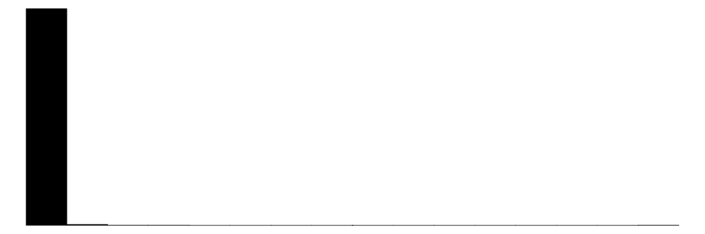

gdp_pc

1934

6

4725.9

8574.1

166.7

1804.3

63886.1

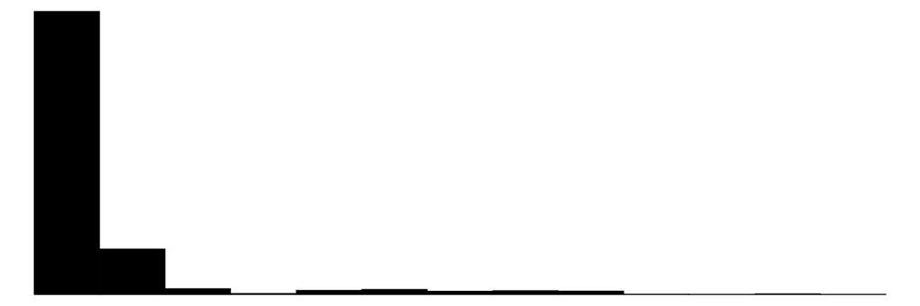

edu

1411

31

94.3

20.7

20.9

98.5

157.7

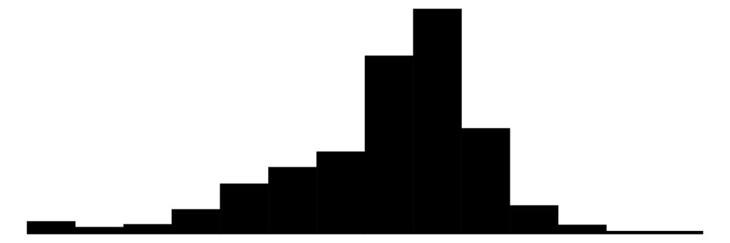

child_mort

1126

6

72.8

62.8

2.8

53.7

478.9

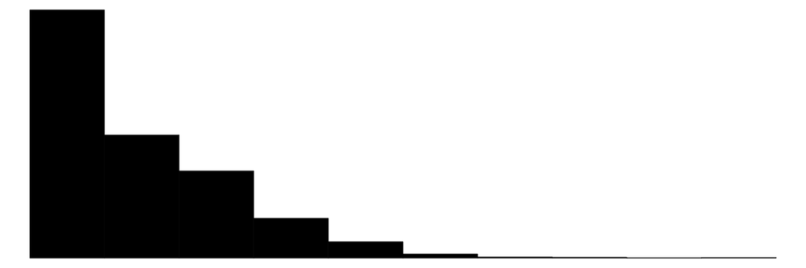

population

1972

4

72350081.6

184083505.1

352205.0

24799014.0

1450935791.0

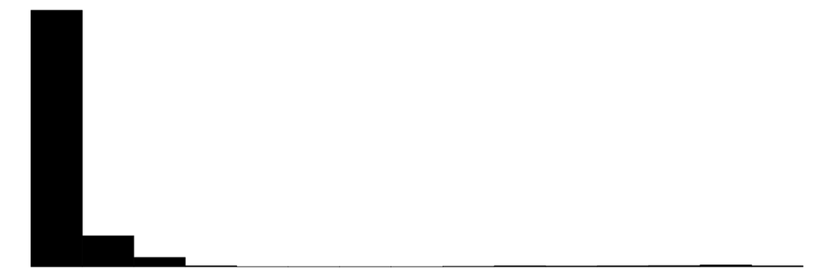

```r
library(modelsummary)

df %>%
  select(total_fatalities, gdp_pc, edu, child_mort, population) %>%
  datasummary_skim(type = "numeric")
```

We can also customise which statistics are shown by using the `datasummary()` function. In `datasummary()`, the left-hand side of the formula specifies the variable or variables to summarise, and the right-hand side specifies which summary statistics to display.

For example, if we want to show the mean, standard deviation, and number of observations for `total_fatalities`, we can write:

```r
library(modelsummary)

datasummary(total_fatalities ~ mean + sd + N, data = df)
```

|  | mean | sd | N |
| --- | --- | --- | --- |
| total_fatalities | 1934.09 | 18504.15 | 2046 |

To produce regression tables with `modelsummary`, we use the `modelsummary()` function. We simply pass a list of model objects, and `modelsummary()` will display them side by side in a table.

```r
library(modelsummary)

modelsummary(list(lm1, lm2, logit1))
```

|  | (1) | (2) | (3) |
| --- | --- | --- | --- |
| (Intercept) | 2253.153 | 8.377 | 3.919 |
|  | (493.798) | (0.350) | (0.805) |
| gdp_pc | -0.067 |  |  |
|  | (0.050) |  |  |
| log(gdp_pc + 1) |  | -0.507 | -0.067 |
|  |  | (0.045) | (0.103) |
| population |  | 0.000 |  |
|  |  | (0.000) |  |
| Num.Obs. | 1933 | 1933 | 1933 |
| R2 | 0.001 | 0.073 |  |
| R2 Adj. | 0.000 | 0.072 |  |
| AIC | 43580.7 | 8968.9 | 552.1 |
| BIC | 43597.4 | 8991.1 | 563.2 |
| Log.Lik. | -21787.338 | -4480.427 | -274.048 |
| RMSE | 19002.34 | 2.46 | 0.18 |

We can also export tables created with `modelsummary()` by using the `output` argument. The file format is determined by the file extension, for example `.txt`, `.html`, `.docx`, or `.xlsx`.

```r
modelsummary(
  list(
    "OLS 1" = lm1,
    "OLS 2" = lm2,
    "Logit 1" = logit1
  ),
  output = "regression.txt"
)
```

## The `corrplot` package

The `corrplot` package is useful for visualising correlation matrices. To use it, we first create a correlation matrix with `cor()`, which calculates correlations between numeric variables. We can then display that matrix with `corrplot()`.

```r
library(corrplot)
library(tidyverse)

df_cor <- df %>%
  select(total_fatalities, gdp_pc, edu, child_mort, population) %>%
  cor(use = "pairwise.complete.obs")

corrplot(df_cor)
```

[figure not shown]

We can also customise the correlation plot by changing the arguments inside `corrplot()`. For example, we can sort variables by their correlations, change the display method, and show only the upper or lower part of the matrix to make the figure easier to read.

```r
corrplot(df_cor, order = "AOE", method = "pie", type = "upper")
```

[figure not shown]

Another useful option is `corrplot.mixed()`, which combines two display styles in the same figure. For example, we can show the correlations as ellipses in the upper half and as numbers in the lower half of the matrix.

```r
corrplot.mixed(df_cor, order = "AOE", upper = "ellipse", lower = "number")
```

[figure not shown]

## The `marginaleffects` package

Another useful package is `marginaleffects`, which helps us interpret statistical models in more substantive terms.

One useful function is `avg_slopes()`, which calculates average marginal effects. These show how the predicted probability of the outcome changes, on average, when an independent variable increases by one unit.

Using our logit model, we can calculate the average marginal effect of `log(gdp_pc + 1)` on the probability of conflict.

```r
library(marginaleffects)
logit2 <- glm(conflict_dummy ~ log(gdp_pc + 1)+ edu + population + child_mort,
              data = df,
              family = binomial(link = "logit"))

avg_slopes(logit2)
```

```
       Term  Estimate Std. Error      z Pr(>|z|)   S     2.5 %    97.5 %
 child_mort -3.00e-04   1.12e-04 -2.687  0.00721 7.1 -5.20e-04 -8.13e-05
 edu        -5.61e-04   2.82e-04 -1.987  0.04687 4.4 -1.11e-03 -7.76e-06
 gdp_pc     -6.01e-06   4.66e-06 -1.290  0.19709 2.3 -1.51e-05  3.12e-06
 population  4.74e-11   5.48e-11  0.866  0.38673 1.4 -5.99e-11  1.55e-10

Type: response
Comparison: dY/dX
```

We can also visualise predicted probabilities with `plot_predictions()`. This allows us to see how the predicted probability of conflict changes across different values of an independent variable.

```r
plot_predictions(
  logit2,
  condition = "edu"
)
```

[figure not shown]

Here we can see that the predicted probability of conflict changes as education levels increase. The overall pattern is negative, meaning that higher levels of school enrollment are associated with a lower predicted probability of conflict. The confidence interval becomes wider at higher values of education, which suggests greater uncertainty in that part of the distribution.

A useful feature of plots created with `marginaleffects` is that they are ordinary `ggplot` objects. This means that we can customise them in the same way as other `ggplot()` figures.

```r
plot_predictions(
  logit2,
  condition = "edu"
) +
  labs(
    x = "Primary school enrolment",
    y = "Predicted probability of conflict"
  ) +
  theme_minimal()
```

[figure not shown]